# Clean and process the raw qualtrics screen

John Curtin and Kendra Wyant

2021-03-09

### Notes

Purpose: This file does cleaning and basic processing of the qualtrics screen survey.

Inputs:

Opens data file in path_in

- screen.csv

Opens log file in path_log

- log_screen.csv

Opens supporting files in path_raw

- raw_notes.csv
- gcal_risk.ics

Output:

Creates file in path_out

- screen.csv

### Setup

Paths

```r
path_in <- "raw_data/qualtrics"
path_out <- "analysis/shared/data"
path_log <- "analysis/shared/notes"
path_raw <- "raw_data"
```

Packages and Source

```r
library(tidyverse)
library(lubridate)
library(janitor)
library(kableExtra)
library(psych)
library(ical)

source('/Volumes/private/toolboxes/lab_support/clean_qualtrics_by_log.R')
```

### Screening survey

#### Load data and glimpse

Load survey and remove unused variables

Rename subid and response_id to tidy case because these variables are used by name in clean_qualtrics_by_log()

```r
screen <- read_csv(file.path(path_in, 'screen.csv'), col_types = cols())  %>%
  select(-c(ResponseSet, IPAddress, RecipientLastName, RecipientFirstName,
            RecipientEmail, ExternalDataReference, Status,
            LocationLatitude, LocationLongitude, LocationAccuracy, DataType,
            DSM5_score, paranoia, psychosis, Psychosis_Final, Paranoia_Final,
            StudyName, DEM_Inst, DEM2_Inst, AUH_Inst, DSM5_Inst, DSM5_Inst2,
            YAP_Inst, ASSIST_Inst, SCL90_Inst, IUS_Inst, ASI_Inst, DTS_Inst,
            FAD_Inst, MPS_Inst, SB_Inst, SB_Inst2, EB_1, EB_2, EB_3, EB_4, Q140)) %>%
  rename(subid = SubID, response_id = ResponseID)  %>%  #update to tidy case for use in clean_qualtrics_by_log()
  relocate(subid) %>%
  glimpse()
```

```
## Rows: 208
## Columns: 509
## $ subid               <dbl> 1, 2, 3, 5, 6, 7, 8, 8, 11, 12, 13, 14, 15, 16, 1…
## $ response_id         <chr> "R_6PxeckNv16lrXFP", "R_WBuA18trr74hZWV", "R_AMBV…
## $ StartDate           <dttm> 2017-02-15 16:35:23, 2017-02-17 20:40:08, 2017-0…
## $ EndDate             <dttm> 2017-02-15 17:25:09, 2017-02-17 21:28:38, 2017-0…
## $ Finished            <dbl> 1, 1, 1, 1, 1, 1, 1, 1, 1, 1, 1, 1, 1, 1, 1, 1, 1…
## $ UTC                 <dbl> NA, NA, NA, 1496249439, 1496852079, 1496938368, 1…
## $ RA                  <chr> "Johnson-Hurwitz", "JohnsonHurwitz", "JohnsonHurw…
## $ DEM_1               <dbl> 57, 35, 22, 39, 22, 38, 22, 38, 25, 45, 63, 50, 5…
## $ DEM_2               <chr> "Male", "Female", "Female", "Male", "Male", "Male…
## $ DEM_3               <chr> "White/Caucasian", "White/Caucasian", "White/Cauc…
## $ DEM_3.1             <chr> NA, NA, NA, NA, NA, NA, NA, NA, "Filipino and Bla…
## $ DEM_4               <chr> "No, I am not of Hispanic, Latino, or Spanish ori…
## $ DEM_4.1             <chr> NA, NA, NA, NA, NA, NA, NA, NA, NA, NA, NA, NA, N…
```

[output cut: 496 more lines]

Open and summarize data log

```r
log_screen <- read_csv(file.path(path_log, "log_screen.csv"), col_types = cols()) %>%
  rowid_to_column("index") %>%
  glimpse()
```

```
## Rows: 69
## Columns: 9
## $ index       <int> 1, 2, 3, 4, 5, 6, 7, 8, 9, 10, 11, 12, 13, 14, 15, 16, 17…
## $ subid       <dbl> 155, 52, 2, 2, 2, 2, 2, 2, 2, 2, 2, 2, 2, 2, 2, 2, 2, 2, …
## $ response_id <chr> "R_3j9vNPmoZjEumL0", "R_1n6LeOMMlaBCqhh", "R_WBuA18trr74h…
## $ log_action  <chr> "note", "recode_one", "recode_one", "recode_one", "recode…
## $ var_name    <chr> NA, "ASSIST_1_8", "ASSIST_3_1", "ASSIST_3_2", "ASSIST_3_3…
## $ old_value   <chr> NA, "Yes", NA, NA, NA, NA, NA, NA, NA, NA, NA, NA, NA, NA…
## $ new_value   <chr> NA, "No", "Never", "Never", "Never", "Never", "Never", "N…
## $ source      <chr> "staff", "staff", "staff", "staff", "staff", "staff", "st…
## $ notes       <chr> "Partial response to ID Screen Battery. Responses to the …
```

```r
tabyl(log_screen$log_action)
```

```
##  log_screen$log_action  n    percent
##                   note  2 0.02898551
##             recode_all  3 0.04347826
##             recode_one 64 0.92753623
```

remove log entries:  
No removed entries

recode_all log entries:

```r
log_screen %>%
  filter(log_action == "recode_all") %>%
  kbl %>%
  kable_styling()
```

| index | subid | response_id | log_action | var_name | old_value | new_value | source | notes |
| --- | --- | --- | --- | --- | --- | --- | --- | --- |
| 45 | NA | NA | recode_all | DEM2_4 | NA | 0 | KW | After discussing with John, we decided that we can reasonably assume people who did not enter a value for parents deceased meant that they have 0 parents deceased |
| 49 | NA | NA | recode_all | DEM2_6 | NA | 0 | KW | After discussing with John, we decided that we can reasonably assume people who did not enter a value for children living meant that they have 0 living children |
| 54 | NA | NA | recode_all | DEM2_8 | NA | 0 | KW | After discussing with John, we decided that we can reasonably assume people who did not enter a value for children deceased meant that they have 0 children deceased |

recode_one log entries:  
Variables with recode_one edits

```r
log_screen %>%
  filter(log_action == "recode_one") %>%
  tabyl(var_name)
```

```
##             var_name n  percent
##           ASSIST_1_8 1 0.015625
##           ASSIST_3_1 1 0.015625
##           ASSIST_3_2 1 0.015625
##           ASSIST_3_3 1 0.015625
##           ASSIST_3_4 1 0.015625
##           ASSIST_3_5 1 0.015625
##           ASSIST_3_6 1 0.015625
##           ASSIST_3_7 1 0.015625
##           ASSIST_3_8 1 0.015625
##           ASSIST_4_1 1 0.015625
##           ASSIST_4_2 1 0.015625
##           ASSIST_4_3 1 0.015625
##           ASSIST_4_4 1 0.015625
##           ASSIST_4_5 1 0.015625
##           ASSIST_4_6 1 0.015625
##           ASSIST_4_7 1 0.015625
##           ASSIST_4_8 1 0.015625
##             ASSIST_8 1 0.015625
##                AUH_1 1 0.015625
##               AUH_10 1 0.015625
##                AUH_2 1 0.015625
##                AUH_4 1 0.015625
##              AUH_6_7 1 0.015625
##              AUH_6.1 1 0.015625
##                AUH_7 1 0.015625
##       AUH_7.1_1_TEXT 1 0.015625
##  AUH_8.1_AUH_8_Month 3 0.046875
##    AUH_8.2_AUH_8_Day 1 0.015625
##   AUH_8.3_AUH_8_Year 3 0.046875
##               DEM2_2 6 0.093750
##               DEM2_4 3 0.046875
##               DEM2_6 4 0.062500
##               DEM2_8 3 0.046875
##              EndDate 2 0.031250
##             Finished 1 0.015625
##            StartDate 2 0.031250
##                subid 5 0.078125
##                  UTC 5 0.078125
```

Changes to subid variable

```r
log_screen %>%
  filter(var_name == "subid") %>%
  select(-index) %>%
  kbl %>%
  kable_styling()
```

| subid | response_id | log_action | var_name | old_value | new_value | source | notes |
| --- | --- | --- | --- | --- | --- | --- | --- |
| 8 | R_3qIO5N1X1tyCWeN | recode_one | subid | 8 | 10 | HM | Subject 10 was missing a screen and subject 8 had two on different dates. On the focal date, there was one scheduled screen for a participant identified as #20312. The screen session form for that day… |
| 22 | R_3p4naYVKxD8b31H | recode_one | subid | 22 | 23 | HM | There are two screen batteries dated October 17, 2017 with the SUBID 022. The RA names and times on session forms support this change. There is only one session screen form for the focal day, and it’s… |
| 149 | R_3mkH0rLyisMbJVT | recode_one | subid | 149 | 150 | HM | Subject 149 has two screens on different days and subject 150 is missing one. Same for the sesion forms. The calendar indicates that subject 150 was in on the focal date. In addition, with these corre… |
| 55 | R_2xzxfV4i1kyOqaU | recode_one | subid | 55 | 61 | HM | A participant was enrolled at two different times with different subids (first 55, then 61). The second time they were enrolled, they participated as usual except that they did not complete a new scre… |
| 79 | R_RCtBJYBoTE7vD2h | recode_one | subid | 79 | 78 | HM | There are 2 total screen surveys subject 79 and zero for 78. The only screen scheudled on the focal day was for 78. There is no screen for 78 on any other day. An RA marked both the session form and t… |

Changes to UTC variable

```r
log_screen %>%
  filter(var_name == "UTC") %>%
  select(-index) %>%
  kbl %>%
  kable_styling()
```

| subid | response_id | log_action | var_name | old_value | new_value | source | notes |
| --- | --- | --- | --- | --- | --- | --- | --- |
| 1 | R_6PxeckNv16lrXFP | recode_one | UTC | NA | 1487176523 | KW | UTC appears to be calculated from Qualtrics start_time - since this was subid 1 and the screener it is likely we were just implementing the utc feature (looks like subids 1-3 are missing a UTC) |
| 9 | R_xyFFfXh1up0Fk5P | recode_one | UTC | 1507242894 | 1498062441 | staff | The screen for subject 009 incorrectly had a subID ‘JohnsonHurwitz;Nagler’ John Retook the response to correct this but it changed the UTC time stamp. The UTC time stamp for 009 should be 1498062441 |
| 2 | R_WBuA18trr74hZWV | recode_one | UTC | NA | 1487364008 | KW | UTC appears to be calculated from Qualtrics start_time - since this was subid 2 and the screener it is likely we were just implementing the utc feature (looks like subids 1-3 are missing UTC) |
| 3 | R_AMBVeDRBZhC5BwB | recode_one | UTC | NA | 1488906926 | KW | UTC appears to be calculated from Qualtrics start_time - since this was subid 3 and the screener it is likely we were just implementing the utc feature (looks like subids 1-3 are missing UTC) |
| 187 | R_3Dpyy1Hk9hsdrCv | recode_one | UTC | 1551210932 | 1549908060 | staff | A screen was completed on 2/11/2019 with participant #187. The subId and study name column were switched. In error, the screen was retaken to fix this mistake and changed the screen completion date to… |

Changes to start or end date variable

```r
log_screen %>%
  filter(var_name == "StartDate" | var_name == "EndDate") %>%
  select(-index) %>%
  kbl %>%
  kable_styling()
```

| subid | response_id | log_action | var_name | old_value | new_value | source | notes |
| --- | --- | --- | --- | --- | --- | --- | --- |
| 9 | R_xyFFfXh1up0Fk5P | recode_one | StartDate | 2017-10-05 21:34:36 | 2017-06-21 16:27:21 | KW | The screen for subject 009 incorrectly had a subID ‘JohnsonHurwitz;Nagler’ John Retook the response to correct this but it changed the UTC time stamp. The UTC time stamp for 009 should be 1498062441 -… |
| 9 | R_xyFFfXh1up0Fk5P | recode_one | EndDate | 2017-10-05 21:36:23 | 2017-06-21 16:27:21 | KW | The screen for subject 009 incorrectly had a subID ‘JohnsonHurwitz;Nagler’ John Retook the response to correct this but it changed the UTC time stamp. The UTC time stamp for 009 should be 1498062441 -… |
| 187 | R_3Dpyy1Hk9hsdrCv | recode_one | StartDate | 2019-02-26 19:55:25 | 2019-02-11 18:01:00 | KW | A screen was completed on 2/11/2019 with participant #187. The subId and study name column were switched. In error, the screen was retaken to fix this mistake and changed the screen completion date to… |
| 187 | R_3Dpyy1Hk9hsdrCv | recode_one | EndDate | 2019-02-26 19:56:51 | 2019-02-11 18:01:00 | KW | A screen was completed on 2/11/2019 with participant #187. The subId and study name column were switched. In error, the screen was retaken to fix this mistake and changed the screen completion date to… |

Other recode-one changes to note

```r
log_screen %>%
  filter(old_value == 40 | old_value == 270 | old_value == 11) %>%
  select(-index) %>%
  kbl %>%
  kable_styling()
```

| subid | response_id | log_action | var_name | old_value | new_value | source | notes |
| --- | --- | --- | --- | --- | --- | --- | --- |
| 32 | R_PYWe6ootFseuFmF | recode_one | AUH_2 | 270 | 27 | KW | They put 27 for age at which they thought their drinking was a problem so likely 270 was a typo for 27 - consulted with John |
| 69 | R_1DCoCD9k16A64C8 | recode_one | DEM2_2 | 11 | 1 | KW | Discussed with John, subid has 1 parent deceased so we are going to assume that 11 is a typo and should be 1 |
| 81 | R_eCCvMBbvz3S2nfP | recode_one | DEM2_6 | 40 | NA | KW | subid 81 reports having 1 parent living, 1 parent decesed, 40 children living, 0 children deceased. 40 children may be a typo for 4 however cannot definitely say so changing to NA. |

note log entries:

```r
log_screen %>%
  filter(log_action == "note") %>%
  kbl %>%
  kable_styling()
```

| index | subid | response_id | log_action | var_name | old_value | new_value | source | notes |
| --- | --- | --- | --- | --- | --- | --- | --- | --- |
| 1 | 155 | R_3j9vNPmoZjEumL0 | note | NA | NA | NA | staff | Partial response to ID Screen Battery. Responses to the survey seemed questionable as to whether the participant was being honest and reading the questions as they responded. The participant took appr… |
| 24 | 84 | R_2CPOwBSKRNP82ll | note | AUH_5 | 365 | NA | KW | Subid 84 put down 365 previous quit attempts. They are 57 years old and first tried to quit drinking at age 26. After discussing with John, we do not think this is a typo. |

Clean raw data using log

```r
screen <- screen %>%
  # temporarily change start and end date to character string for cleaning function to work
  mutate(StartDate = as.character(StartDate),
         EndDate = as.character(EndDate)) %>%
  clean_qualtrics_by_log(., log_screen) %>%
  # change start and end date back to date time
   mutate(StartDate = as_datetime(StartDate),
         EndDate = as_datetime(EndDate))
```

Tidy variable names

```r
screen <- clean_names(screen, "snake") %>%
  rename(auh_8_month = auh_8_1_auh_8_month, auh_8_day = auh_8_2_auh_8_day,
         auh_8_year = auh_8_3_auh_8_year, auh_7_med1 = auh_7_1_1_text,
         auh_7_med2 = auh_7_1_2_text, auh_7_med3 = auh_7_1_3_text,
         auh_7_med4 = auh_7_1_4_text,
         auh_6_7_text = auh_6_1_2)
```

Tidy response options Some response options contain two back slashes or - will remove for consistency

```r
screen <- screen %>%
  mutate(across(where(is.character), str_replace_all, pattern = "\\\\", replacement = " "),
         across(where(is.character), str_replace_all, pattern = "&nbsp;", replacement = ""))
```

#### EDA and Save

```r
kabyl <- compose(
  partial(kable_classic, position = "left"),
  partial(kbl, digits = 2, table.attr = "style='width:50%;'"),
  partial(tabyl, dat = screen)
)
```

```r
screen %>%
  glimpse()
```

```
## Rows: 208
## Columns: 509
## $ subid        <dbl> 1, 2, 3, 5, 6, 7, 8, 10, 11, 12, 13, 14, 15, 16, 17, 9, …
## $ response_id  <chr> "R_6PxeckNv16lrXFP", "R_WBuA18trr74hZWV", "R_AMBVeDRBZhC…
## $ start_date   <dttm> 2017-02-15 16:35:23, 2017-02-17 20:40:08, 2017-03-07 17…
## $ end_date     <dttm> 2017-02-15 17:25:09, 2017-02-17 21:28:38, 2017-03-07 17…
## $ finished     <dbl> 1, 1, 1, 1, 1, 1, 1, 1, 1, 1, 1, 1, 1, 1, 1, 1, 1, 1, 1,…
## $ utc          <dbl> 1487176523, 1487364008, 1488906926, 1496249439, 14968520…
## $ ra           <chr> "Johnson-Hurwitz", "JohnsonHurwitz", "JohnsonHurwitz", "…
## $ dem_1        <dbl> 57, 35, 22, 39, 22, 38, 22, 38, 25, 45, 63, 50, 53, 26, …
## $ dem_2        <chr> "Male", "Female", "Female", "Male", "Male", "Male", "Fem…
## $ dem_3        <chr> "White/Caucasian", "White/Caucasian", "White/Caucasian",…
## $ dem_3_1      <chr> NA, NA, NA, NA, NA, NA, NA, NA, "Filipino and Black", NA…
## $ dem_4        <chr> "No, I am not of Hispanic, Latino, or Spanish origin", "…
## $ dem_4_1      <chr> NA, NA, NA, NA, NA, NA, NA, NA, NA, NA, NA, NA, NA, NA, …
```

[output cut: 496 more lines]

208 participants contribute to a total of 208 reports.

216 participants were screened - we have session form screen data but no participant survey screen data for 8 withdrawn/discontinued subids:  
4 - discontinued (did not enroll) but no notes why  
68 - Deemed ineligible during screen visit - Ineligible phone  
70 - ineligible due to phone (Samsung Galaxy 4)  
75 - Ineligible due to phone (Samsung Galaxy S7)  
133 - did not sign study consent form  
142 - Participant was ineligible because she had a temporary goal of abstinence until 12/20  
144 - The participant will need to complete a screening session again if he wants to re-enroll in the project. He did sign a consent form. However, he did not reach seven days without drinking at the time of the screening session. He is interested in the study and will call back when he has a more concrete goal of sobriety.  
148 - Does not meet criteria for moderate-severe alcohol use disorder (not sure why screen data is not showing up in data file)

##### Dates and Times

The earliest recorded report is from 2017-02-15 16:35:23 and the most recent is from 2019-09-19 16:40:28.

All timezones in UTC

```r
screen %>%
  select(start_date, end_date) %>%
  map(tz)
```

```
## $start_date
## [1] "UTC"
##
## $end_date
## [1] "UTC"
```

**Time difference in start_date and utc**

```r
options(tibble.print_max = Inf)
screen %>%
  select(subid, start_date, end_date, utc) %>%
  mutate(utc = lubridate::as_datetime(utc, tz = "utc")) %>%
  mutate(diff = round(difftime(utc, start_date, units = "mins")), 0) %>%
  tabyl(diff)
```

```
##      diff  n     percent
##    0 mins 41 0.197115385
##    1 mins 23 0.110576923
##    2 mins  4 0.019230769
##    8 mins  1 0.004807692
##   12 mins  1 0.004807692
##   43 mins  1 0.004807692
##   47 mins  1 0.004807692
##   51 mins  1 0.004807692
##   54 mins  1 0.004807692
##   60 mins 68 0.326923077
##   61 mins 38 0.182692308
##   62 mins 10 0.048076923
##   63 mins  3 0.014423077
##   64 mins  1 0.004807692
##   66 mins  2 0.009615385
##   67 mins  1 0.004807692
##   76 mins  1 0.004807692
##   80 mins  1 0.004807692
##   81 mins  1 0.004807692
##  101 mins  1 0.004807692
##  116 mins  1 0.004807692
##  121 mins  1 0.004807692
##  125 mins  1 0.004807692
##  143 mins  1 0.004807692
##  151 mins  1 0.004807692
##  188 mins  1 0.004807692
##  230 mins  1 0.004807692
```

No info from notes on subids with a 2 hour difference

```r
notes <- read_csv("./raw_data/raw_notes.csv", col_types = cols()) %>%
  select(subid, notes_general)
subs_2hrs <- screen %>%
  select(subid, start_date, end_date, utc) %>%
  mutate(utc = lubridate::as_datetime(utc, tz = "utc")) %>%
  mutate(diff = difftime(utc, start_date, units = "mins")) %>%
  filter(diff > 120)
notes %>%
  filter(subid %in% subs_2hrs$subid) %>%
  kbl() %>%
  kable_styling()
```

| subid | notes_general |
| --- | --- |
| 56 | Two intake surveys on same date - first intake survey only answered to sfir_9 and then duplicate entry started from beginning. removed incomplete entry; 4/10/2018 through 4/13/2018: Participant receiv… |
| 58 | NA |
| 60 | No attempt made to schedule intake; according to enrollment db they were deemed ineligible after screening session (no notes why and marked eligible on screen session form - one note: Eligibility stat… |
| 61 | 2/3/21 KW: Subject 55 was continued as subject 61 after a brief discontinuation. We are using their previous screen completed as subject 55, but a new intake completed as subject 61. All other files h… |
| 64 | Participant experienced a handful of times over the course of their participation during which their phone service was disconnected (as they had a state subsidized phone) so they were occasionally una… |
| 151 | NA |

**Time difference in start and end date**

```r
screen_diff <- screen %>%
  mutate(diff = round(difftime(end_date, start_date, units = "mins")),
         diff_mins = as.numeric(str_replace(diff, " mins", "")))

freq <- hist(screen_diff$diff_mins, breaks = c(seq(0, 320, 10)), include.lowest=TRUE, plot=FALSE)
tibble(mins = freq$breaks[-1], frequency = freq$counts)
```

```
## # A tibble: 32 x 2
##     mins frequency
##    <dbl>     <int>
##  1    10         2
##  2    20         0
##  3    30         3
##  4    40        19
##  5    50        29
##  6    60        35
##  7    70        28
##  8    80        21
##  9    90        16
## 10   100        11
## 11   110        14
## 12   120         5
```

[output cut: 20 more lines]

25 subids have start and end time difference of more than 2 hours apart.

Start and end dates less than 15 minutes apart (9 and 187 - these are expected as their start and end date were corrected to match utc via log)

```r
screen %>%
  select(subid, start_date, end_date, utc) %>%
  mutate(utc = lubridate::as_datetime(utc, tz = "utc")) %>%
  mutate(diff = difftime(end_date, start_date, units = "secs")) %>%
  filter(diff < 900)
```

```
## # A tibble: 2 x 5
##   subid start_date          end_date            utc                 diff
##   <dbl> <dttm>              <dttm>              <dttm>              <drtn>
## 1     9 2017-06-21 16:27:21 2017-06-21 16:27:21 2017-06-21 16:27:21 0 secs
## 2   187 2019-02-11 18:01:00 2019-02-11 18:01:00 2019-02-11 18:01:00 0 secs
```

5 subids have start and end time difference of more than 3 hours apart.  
Notes for subids with more than a 3 hour time difference - only subid 155 has notes explaining long screen session.

```r
subs_3hrs <- screen %>%
  select(subid, start_date, end_date, utc) %>%
  mutate(utc = lubridate::as_datetime(utc, tz = "utc")) %>%
  mutate(diff = difftime(end_date, start_date, units = "mins")) %>%
  filter(diff > 180)
notes %>%
  filter(subid %in% subs_3hrs$subid) %>%
  kbl() %>%
  kable_styling()
```

| subid | notes_general |
| --- | --- |
| 58 | NA |
| 60 | No attempt made to schedule intake; according to enrollment db they were deemed ineligible after screening session (no notes why and marked eligible on screen session form - one note: Eligibility stat… |
| 64 | Participant experienced a handful of times over the course of their participation during which their phone service was disconnected (as they had a state subsidized phone) so they were occasionally una… |
| 151 | NA |
| 155 | Partial response to ID Screen Battery. Responses to the survey seemed questionable as to whether the participant was being honest and reading the questions as they responded. The participant took appr… |

##### Missing values

```r
screen %>%
  naniar::miss_var_summary() %>%
  kbl(table.attr = "style='width:40%;'") %>%
  kable_classic(position = "l") %>%
  add_header_above(c("Missing values by variable" = 3), bold = TRUE) %>%
  scroll_box(height = "500px")
```

| Missing values by variable variable | Missing values by variable n_miss | Missing values by variable pct_miss |
| --- | --- | --- |
| dem_4_1 | 207 | 99.5192308 |
| auh_7_med4 | 201 | 96.6346154 |
| dem_3_1 | 197 | 94.7115385 |
| auh_6_1 | 194 | 93.2692308 |
| auh_7_med3 | 193 | 92.7884615 |
| auh_7_med2 | 172 | 82.6923077 |
| assist_2_5 | 161 | 77.4038462 |
| assist_5_5 | 161 | 77.4038462 |
| assist_6_5 | 161 | 77.4038462 |
| assist_7_5 | 161 | 77.4038462 |
| assist_3_5 | 160 | 76.9230769 |
| assist_4_5 | 159 | 76.4423077 |
| auh_6_7 | 156 | 75.0000000 |
| auh_6_7_text | 156 | 75.0000000 |
| auh_6_2 | 143 | 68.7500000 |
| auh_6_5 | 126 | 60.5769231 |
| assist_2_8 | 125 | 60.0961538 |
| assist_3_8 | 125 | 60.0961538 |
| assist_4_8 | 125 | 60.0961538 |
| assist_5_8 | 125 | 60.0961538 |
| assist_6_8 | 125 | 60.0961538 |
| assist_7_8 | 125 | 60.0961538 |
| auh_7_med1 | 124 | 59.6153846 |
| assist_2_6 | 116 | 55.7692308 |
| assist_3_6 | 116 | 55.7692308 |
| assist_4_6 | 116 | 55.7692308 |
| assist_5_6 | 116 | 55.7692308 |
| assist_6_6 | 116 | 55.7692308 |
| assist_7_6 | 116 | 55.7692308 |
| auh_6_3 | 104 | 50.0000000 |

[output cut: 479 more lines]

Missing values all seem to be appropriate (i.e., conditional questions that did not apply to everyone)  
Missing mps variables is due to subid 155 not completing survey and failing screen due to questionable/dishonest behavior:  
“The participant took approximately 2.5 hours to complete 78% of the survey before research staff ended the session.”

##### Finished

```r
kabyl(finished)

screen %>%
  filter(finished == 0) %>%
  kbl() %>%
  kable_styling() %>%
  scroll_box(width = "100%")
```

| finished | n | percent |
| --- | --- | --- |
| 0 | 1 | 0 |
| 1 | 207 | 1 |

| subid | response_id | start_date | end_date | finished | utc | ra | dem_1 | dem_2 | dem_3 | dem_3_1 | dem_4 | dem_4_1 | dem_5 | dem_6 | dem_6_1 | dem_7 | dem_8 | dem2_2 | dem2_4 | dem2_6 | dem2_8 | auh_1 | auh_2 | auh_3 | auh_4 | auh_5 | auh_6_1 | auh_6_2 | auh_6_3 | … |
| --- | --- | --- | --- | --- | --- | --- | --- | --- | --- | --- | --- | --- | --- | --- | --- | --- | --- | --- | --- | --- | --- | --- | --- | --- | --- | --- | --- | --- | --- | --- |
| 155 | R_3j9vNPmoZjEumL0 | 2018-10-26 15:12:18 | 2018-10-26 18:13:46 | 0 | 1540570354 | Keiser | 22 | Male | Other/Multiracial | Hispanic | Yes, Mexican, Mexican American, Chicano | NA | Some college | Unemployed | NA | 1150 | Never Married | 3 | 1 | 4 | 0 | 14 | 15 | 17 | 18 | 9 | NA | Short-Term Residential Treatment (less than 6 months) | NA | … |

Subid 155 is correctly marked as incorrect. See note above.

##### RA

```r
kabyl(ra)
```

| ra | n | percent |
| --- | --- | --- |
| Jill Nagler, Sarah Sant’Ana | 1 | 0.00 |
| Johnson-Hurwitz | 1 | 0.00 |
| Johnson-Hurwitz; Nagler | 1 | 0.00 |
| JohnsonHurwitz | 66 | 0.32 |
| JohnsonHurwitz; Keiser | 2 | 0.01 |
| JohnsonHurwitz; kittleson | 1 | 0.00 |
| JohnsonHurwitz; Nagler | 6 | 0.03 |
| Keiser | 51 | 0.25 |
| Keiser; Nagler | 3 | 0.01 |
| Nagler | 69 | 0.33 |
| Nagler; Johnson-Hurwitz | 1 | 0.00 |
| Nagler; Keiser | 2 | 0.01 |
| Nagler; Kittleson | 1 | 0.00 |
| Nagler; Schultz | 1 | 0.00 |
| Naglet | 1 | 0.00 |
| Santana | 1 | 0.00 |

##### Demographics

Age

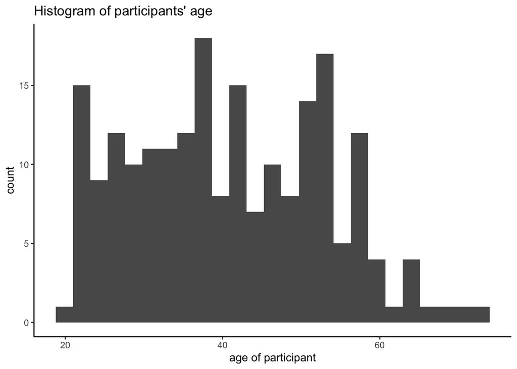

```
## # A tibble: 1 x 3
##     min   max  mean
##   <dbl> <dbl> <dbl>
## 1    19    72  40.9
```

```r
screen %>%
  summarise(min = min(dem_1, na.rm = TRUE),
            max = max(dem_1, na.rm = TRUE),
            mean = mean(dem_1, na.rm = TRUE))

screen %>%
  ggplot(aes(x = dem_1)) +
  geom_histogram(bins = 25) +
  xlab("age of participant") +
  ggtitle("Histogram of participants' age") +
  theme_classic()
```

Sex

```r
kabyl(dem_2)
```

| dem_2 | n | percent |
| --- | --- | --- |
| Female | 101 | 0.49 |
| Male | 107 | 0.51 |

Race

```r
kabyl(dem_3)
```

| dem_3 | n | percent |
| --- | --- | --- |
| American Indian/Alaska Native | 3 | 0.01 |
| Asian | 2 | 0.01 |
| Black/African American | 13 | 0.06 |
| Native Hawaiian or Other Pacific Islander | 1 | 0.00 |
| Other/Multiracial | 11 | 0.05 |
| White/Caucasian | 178 | 0.86 |

Other race specified

```r
kabyl(dem_3_1)
```

| dem_3_1 | n | percent | valid_percent |
| --- | --- | --- | --- |
| African American and white | 1 | 0.00 | 0.09 |
| Ashkenazi | 1 | 0.00 | 0.09 |
| BiRacial | 1 | 0.00 | 0.09 |
| Black | 1 | 0.00 | 0.09 |
| Filipino and Black | 1 | 0.00 | 0.09 |
| Hispanic | 2 | 0.01 | 0.18 |
| Human | 1 | 0.00 | 0.09 |
| Korean caucasian | 1 | 0.00 | 0.09 |
| Latino | 1 | 0.00 | 0.09 |
| Mexican | 1 | 0.00 | 0.09 |
| NA | 197 | 0.95 | NA |

Ethnicity

```r
kabyl(dem_4)
```

| dem_4 | n | percent |
| --- | --- | --- |
| No, I am not of Hispanic, Latino, or Spanish origin | 202 | 0.97 |
| Yes, another Hispanic, Latino, or Spanish origin | 1 | 0.00 |
| Yes, Mexican, Mexican American, Chicano | 5 | 0.02 |

Ethnicity other

```r
kabyl(dem_4_1)
```

| dem_4_1 | n | percent | valid_percent |
| --- | --- | --- | --- |
| Costs Rica | 1 | 0 | 1 |
| NA | 207 | 1 | NA |

Education

```r
kabyl(dem_5)
```

| dem_5 | n | percent |
| --- | --- | --- |
| 2-Year degree | 18 | 0.09 |
| Advanced degree | 29 | 0.14 |
| College degree | 69 | 0.33 |
| High school or GED | 21 | 0.10 |
| Less than high school or GED degree | 5 | 0.02 |
| Some college | 66 | 0.32 |

Work

```r
kabyl(dem_6)
```

| dem_6 | n | percent |
| --- | --- | --- |
| Disabled | 16 | 0.08 |
| Employed | 126 | 0.61 |
| Full-time student | 8 | 0.04 |
| Homemaker | 3 | 0.01 |
| Other, not otherwise specified | 11 | 0.05 |
| Retired | 11 | 0.05 |
| Temporarily laid off, sick leave, or maternity leave | 5 | 0.02 |
| Unemployed | 28 | 0.13 |

Work - part or full time

```r
kabyl(dem_6_1)
```

| dem_6_1 | n | percent | valid_percent |
| --- | --- | --- | --- |
| Full-time | 90 | 0.43 | 0.71 |
| Part-time | 36 | 0.17 | 0.29 |
| NA | 82 | 0.39 | NA |

Income

```r
screen %>%
  summarise(min = min(as.numeric(dem_7), na.rm = TRUE),
            max = max(as.numeric(dem_7), na.rm = TRUE),
            mean = mean(as.numeric(dem_7), na.rm = TRUE))
```

```
## # A tibble: 1 x 3
##     min    max   mean
##   <dbl>  <dbl>  <dbl>
## 1     0 200000 31492.
```

Marital status

```r
kabyl(dem_8)
```

| dem_8 | n | percent |
| --- | --- | --- |
| Divorced | 58 | 0.28 |
| Married | 40 | 0.19 |
| Never Married | 97 | 0.47 |
| Separated | 9 | 0.04 |
| Widowed | 4 | 0.02 |

living parents

```r
screen %>%
  summarise(min = min(as.numeric(dem2_2), na.rm = TRUE),
            max = max(as.numeric(dem2_2), na.rm = TRUE),
            mean = mean(as.numeric(dem2_2), na.rm = TRUE))
```

```
## # A tibble: 1 x 3
##     min   max  mean
##   <dbl> <dbl> <dbl>
## 1     0     6  1.72
```

deceased parents

```r
screen %>%
  summarise(min = min(as.numeric(dem2_4), na.rm = TRUE),
            max = max(as.numeric(dem2_4), na.rm = TRUE),
            mean = mean(as.numeric(dem2_4), na.rm = TRUE))
```

```
## # A tibble: 1 x 3
##     min   max  mean
##   <dbl> <dbl> <dbl>
## 1     0     4 0.575
```

living children

```r
screen %>%
  summarise(min = min(as.numeric(dem2_6), na.rm = TRUE),
            max = max(as.numeric(dem2_6), na.rm = TRUE),
            mean = mean(as.numeric(dem2_6), na.rm = TRUE))
```

```
## # A tibble: 1 x 3
##     min   max  mean
##   <dbl> <dbl> <dbl>
## 1     0    10  1.20
```

deceased children

```r
screen %>%
  summarise(min = min(as.numeric(dem2_8), na.rm = TRUE),
            max = max(as.numeric(dem2_8), na.rm = TRUE),
            mean = mean(as.numeric(dem2_8), na.rm = TRUE))
```

```
## # A tibble: 1 x 3
##     min   max   mean
##   <dbl> <dbl>  <dbl>
## 1     0     4 0.0829
```

##### Alcohol use history

age of first drink

```r
screen %>%
  summarise(min = min(as.numeric(auh_1), na.rm = TRUE),
            max = max(as.numeric(auh_1), na.rm = TRUE),
            mean = mean(as.numeric(auh_1), na.rm = TRUE))
```

```
## # A tibble: 1 x 3
##     min   max  mean
##   <dbl> <dbl> <dbl>
## 1     2    26  14.4
```

0 participants reported age of first drink as higher than current age.

age of regular drinking

```r
screen %>%
  summarise(min = min(as.numeric(auh_2), na.rm = TRUE),
            max = max(as.numeric(auh_2), na.rm = TRUE),
            mean = mean(as.numeric(auh_2), na.rm = TRUE))
```

```
## # A tibble: 1 x 3
##     min   max  mean
##   <dbl> <dbl> <dbl>
## 1     9    56  18.9
```

age at which thought drinking was a problem

```r
screen %>%
  summarise(min = min(as.numeric(auh_3), na.rm = TRUE),
            max = max(as.numeric(auh_3), na.rm = TRUE),
            mean = mean(as.numeric(auh_3), na.rm = TRUE))
```

```
## # A tibble: 1 x 3
##     min   max  mean
##   <dbl> <dbl> <dbl>
## 1    12    60  27.6
```

0 participants reported age of problem drinking as higher than current age.

age at first quit

```r
screen %>%
  summarise(min = min(as.numeric(auh_4), na.rm = TRUE),
            max = max(as.numeric(auh_4), na.rm = TRUE),
            mean = mean(as.numeric(auh_4), na.rm = TRUE))
```

```
## # A tibble: 1 x 3
##     min   max  mean
##   <dbl> <dbl> <dbl>
## 1    15    65  31.3
```

0 participants reported age of first quit as higher than current age.

Number of quit attempts

```r
screen %>%
  summarise(min = min(as.numeric(auh_5), na.rm = TRUE),
            max = max(as.numeric(auh_5), na.rm = TRUE),
            mean = mean(as.numeric(auh_5), na.rm = TRUE))
```

```
## # A tibble: 1 x 3
##     min   max  mean
##   <dbl> <dbl> <dbl>
## 1     0   365  10.5
```

Participants with 0 quit attempts

```r
screen %>%
  select(subid, auh_5) %>%
  filter(auh_5 == 0)
```

```
## # A tibble: 7 x 2
##   subid auh_5
##   <dbl> <dbl>
## 1     5     0
## 2    59     0
## 3    69     0
## 4    86     0
## 5   168     0
## 6   226     0
## 7   264     0
```

7 participants report 0 quit attempts. Subids 59, 86, and 264 enrolled in the study.

Participants with more than 100 quit attempts

```r
screen %>%
  select(subid,
         quit_attempts = auh_5) %>%
  filter(quit_attempts > 100)
```

```
## # A tibble: 1 x 2
##   subid quit_attempts
##   <dbl>         <dbl>
## 1    84           365
```

Types of treatments

```r
kabyl(auh_6_1)
kabyl(auh_6_2)
kabyl(auh_6_3)
kabyl(auh_6_4)
kabyl(auh_6_5)
kabyl(auh_6_6)
kabyl(auh_6_7)
kabyl(auh_6_7_text) %>%
  scroll_box(height = "500px")
```

| auh_6_1 | n | percent | valid_percent |
| --- | --- | --- | --- |
| Long-Term Residential Treatment (more than 6 months) | 14 | 0.07 | 1 |
| NA | 194 | 0.93 | NA |

| auh_6_2 | n | percent | valid_percent |
| --- | --- | --- | --- |
| Short-Term Residential Treatment (less than 6 months) | 65 | 0.31 | 1 |
| NA | 143 | 0.69 | NA |

| auh_6_3 | n | percent | valid_percent |
| --- | --- | --- | --- |
| Outpatient Treatment | 104 | 0.5 | 1 |
| NA | 104 | 0.5 | NA |

| auh_6_4 | n | percent | valid_percent |
| --- | --- | --- | --- |
| Individual Counseling | 134 | 0.64 | 1 |
| NA | 74 | 0.36 | NA |

| auh_6_5 | n | percent | valid_percent |
| --- | --- | --- | --- |
| Group Counseling | 82 | 0.39 | 1 |
| NA | 126 | 0.61 | NA |

| auh_6_6 | n | percent | valid_percent |
| --- | --- | --- | --- |
| Alcoholics Anonymous/Narcotics Anonymous | 133 | 0.64 | 1 |
| NA | 75 | 0.36 | NA |

| auh_6_7 | n | percent | valid_percent |
| --- | --- | --- | --- |
| Other | 52 | 0.25 | 1 |
| NA | 156 | 0.75 | NA |

| auh_6_7_text | n | percent | valid_percent |
| --- | --- | --- | --- |
| Cold Turkey | 2 | 0.01 | 0.04 |
| Detox | 1 | 0.00 | 0.02 |
| Friends helped | 1 | 0.00 | 0.02 |
| Group therapy | 1 | 0.00 | 0.02 |
| Havent Used any | 1 | 0.00 | 0.02 |
| In between careers | 1 | 0.00 | 0.02 |
| incarceration | 1 | 0.00 | 0.02 |
| Indiidual | 1 | 0.00 | 0.02 |
| Mindfulness | 1 | 0.00 | 0.02 |
| Moving | 1 | 0.00 | 0.02 |
| Never used prg | 1 | 0.00 | 0.02 |
| No resource | 1 | 0.00 | 0.02 |
| No services used | 1 | 0.00 | 0.02 |
| None | 6 | 0.03 | 0.12 |
| Not Applicable | 1 | 0.00 | 0.02 |
| Nothing | 1 | 0.00 | 0.02 |
| On line | 1 | 0.00 | 0.02 |
| On my own | 1 | 0.00 | 0.02 |
| On my own will power | 1 | 0.00 | 0.02 |
| One year no beer | 1 | 0.00 | 0.02 |
| Online forums | 1 | 0.00 | 0.02 |
| Online support groups | 1 | 0.00 | 0.02 |
| Other | 1 | 0.00 | 0.02 |
| Personal discipline and faith | 1 | 0.00 | 0.02 |
| Psychiatric treatment | 1 | 0.00 | 0.02 |
| Reflective writing with low dose hallucinagens | 1 | 0.00 | 0.02 |
| Refuge Recovery | 1 | 0.00 | 0.02 |
| Self abstinance | 1 | 0.00 | 0.02 |
| Self administration | 1 | 0.00 | 0.02 |
| Self control | 1 | 0.00 | 0.02 |
| Self disapline | 1 | 0.00 | 0.02 |
| Self help books | 1 | 0.00 | 0.02 |
| Self medicated | 1 | 0.00 | 0.02 |
| Self treatment | 1 | 0.00 | 0.02 |
| SMART | 2 | 0.01 | 0.04 |
| Smart recovery | 4 | 0.02 | 0.08 |
| Smart Recovery | 1 | 0.00 | 0.02 |
| SMART Recovery | 1 | 0.00 | 0.02 |
| Tried on my own and some Neuro linguistic lrogramming | 1 | 0.00 | 0.02 |
| unclick other | 1 | 0.00 | 0.02 |
| Will power | 1 | 0.00 | 0.02 |
| Work place provided employee assistance program | 1 | 0.00 | 0.02 |
| NA | 156 | 0.75 | NA |

Taken prescription medication for alcohol treatment

```r
kabyl(auh_7)
```

| auh_7 | n | percent |
| --- | --- | --- |
| No | 124 | 0.6 |
| Yes | 84 | 0.4 |

Types of medication

```r
screen %>%
  select(contains("med")) %>%
  gather(med_var, medication, auh_7_med1:auh_7_med4) %>%
  filter(!is.na(medication)) %>%
  group_by(medication) %>%
  summarise(n = n()) %>%
  kbl(table.attr = "style='width:50%;'") %>%
  kable_classic(position = "l") %>%
  scroll_box(height = "400px")
```

| medication | n |
| --- | --- |
| Acamprosate | 3 |
| Acomprosate | 3 |
| Amoxapine | 1 |
| Anabuse | 3 |
| Anibuse | 1 |
| antabuse | 1 |
| Antabuse | 11 |
| Antebuse | 1 |
| Antibuse | 7 |
| Baclofen | 1 |
| Buproion | 1 |
| Bupropian | 1 |
| Buspar | 1 |
| Campral | 5 |
| Camprol | 1 |
| Camprosate | 1 |
| Chlorthidone | 1 |
| Clonazepam | 1 |
| Clonidine | 1 |
| Dexapro | 1 |
| Disulfiram | 2 |
| Disulfirum | 1 |
| Do not remember name | 1 |
| Doxazosin placebo | 1 |
| Doxepin | 1 |
| Doxitosen | 1 |
| Doxozisn | 1 |
| Ecitalopram | 1 |
| Effexor | 1 |
| Forgot | 1 |
| Gabapartein | 1 |
| Gabapenten | 1 |
| Gabapentin | 12 |
| Gabepentin | 1 |
| Hydroxazine | 1 |
| Lexapro | 2 |
| Lexipro | 1 |
| Lopazepam | 1 |
| Lorazepam | 1 |
| Microgestin | 1 |
| Naltrexone | 33 |
| Naltrexzon | 1 |
| Naltrexzone | 1 |
| Nuerontin | 1 |
| Seroquel | 1 |
| Seroquil | 1 |
| Sertraline | 2 |
| Silidipfil | 1 |
| Suboxene | 1 |
| Suboxone | 1 |
| Trazadone | 2 |
| Vivatral | 1 |
| Vivatrol | 2 |
| Vivitral | 1 |
| Vivitrol | 10 |
| Vivotrol | 1 |
| Welbutrin | 1 |
| Well butrin | 1 |
| Xanax | 1 |

Most recent quit date - month

```r
kabyl(auh_8_month)
```

| auh_8_month | n | percent |
| --- | --- | --- |
| April | 17 | 0.08 |
| August | 14 | 0.07 |
| December | 15 | 0.07 |
| February | 19 | 0.09 |
| January | 23 | 0.11 |
| July | 21 | 0.10 |
| June | 22 | 0.11 |
| March | 18 | 0.09 |
| May | 19 | 0.09 |
| November | 5 | 0.02 |
| October | 14 | 0.07 |
| September | 21 | 0.10 |

Most recent quit date - day

```r
screen %>%
  summarise(min = min(as.numeric(auh_8_day), na.rm = TRUE),
            max = max(as.numeric(auh_8_day), na.rm = TRUE),
            mean = mean(as.numeric(auh_8_day), na.rm = TRUE))
```

```
## # A tibble: 1 x 3
##     min   max  mean
##   <dbl> <dbl> <dbl>
## 1     1    31  15.4
```

Most recent quit date - year

```r
screen %>%
  summarise(min = min(as.numeric(auh_8_year), na.rm = TRUE),
            max = max(as.numeric(auh_8_year), na.rm = TRUE),
            mean = mean(as.numeric(auh_8_year), na.rm = TRUE))
```

```
## # A tibble: 1 x 3
##     min   max  mean
##   <dbl> <dbl> <dbl>
## 1  2016  2019 2018.
```

Check most recent quit dates against screening visit date

```r
screen %>%
  mutate(auh_8_month = case_when(auh_8_month == "January" ~ 1,
                                 auh_8_month == "February" ~ 2,
                                 auh_8_month == "March" ~ 3,
                                 auh_8_month == "April" ~ 4,
                                 auh_8_month == "May" ~ 5,
                                 auh_8_month == "June" ~ 6,
                                 auh_8_month == "July" ~ 7,
                                 auh_8_month == "August" ~ 8,
                                 auh_8_month == "September" ~ 9,
                                 auh_8_month == "October" ~ 10,
                                 auh_8_month == "November" ~ 11,
                                 auh_8_month == "December" ~ 12)) %>%
  mutate(quit_date = make_date(auh_8_year, auh_8_month, auh_8_day)) %>%
  mutate(screen_date = as_date(start_date)) %>%
  filter(quit_date > screen_date) %>%
  select(subid, screen_date, quit_date) %>%
  kable(table.attr = "style='width:60%;'", align = c("l", "c", "r")) %>%
  kable_classic(position = "left") %>%
  add_header_above(c("quit dates that are greater than screening visit" = 3))
```

| quit dates that are greater than screening visit | quit dates that are greater than screening visit | quit dates that are greater than screening visit |
| --- | --- | --- |
| subid | screen_date | quit_date |

Days per week drinking - 6 months prior to quitting

```r
screen %>%
  summarise(min = min(as.numeric(auh_9), na.rm = TRUE),
            max = max(as.numeric(auh_9), na.rm = TRUE),
            mean = mean(as.numeric(auh_9), na.rm = TRUE))
```

```
## # A tibble: 1 x 3
##     min   max  mean
##   <dbl> <dbl> <dbl>
## 1     1     7  5.20
```

Days per week drinking 6 or more drinks - 6 months prior to quitting

```r
screen %>%
  summarise(min = min(as.numeric(auh_10), na.rm = TRUE),
            max = max(as.numeric(auh_10), na.rm = TRUE),
            mean = mean(as.numeric(auh_10), na.rm = TRUE))
```

```
## # A tibble: 1 x 3
##     min   max  mean
##   <dbl> <dbl> <dbl>
## 1     0     7  4.08
```

Average drinks per drinking day - 6 months prior to quitting

```r
screen %>%
  summarise(min = min(as.numeric(auh_11), na.rm = TRUE),
            max = max(as.numeric(auh_11), na.rm = TRUE),
            mean = mean(as.numeric(auh_11), na.rm = TRUE))
```

```
## # A tibble: 1 x 3
##     min   max  mean
##   <dbl> <dbl> <dbl>
## 1     0    40  7.67
```

participants with average of 0 drinks per day - 6 months prior to quitting

```r
screen %>%
  filter(auh_11 == 0) %>%
  select(subid, auh_11)
```

```
## # A tibble: 1 x 2
##   subid auh_11
##   <dbl>  <dbl>
## 1   256      0
```

Subid 256 reported 0 drinks per day on average but screened ineligible for study and was not enrolled.

more than 20 drinks per drinking day - 6 months prior to quitting

```r
screen %>%
  filter(auh_11 > 20) %>%
  select(subid, drinks = auh_11) %>%
  arrange(desc(drinks))
```

```
## # A tibble: 2 x 2
##   subid drinks
##   <dbl>  <dbl>
## 1   260     40
## 2   230     25
```

Two people reported an average of more than 20 drinks per day:  
Subid 260 was never enrolled in study.  
Subid 230 completed study.

Days per week drinking - over 6 months of heaviest lifetime drinking

```r
screen %>%
  summarise(min = min(as.numeric(auh_12), na.rm = TRUE),
            max = max(as.numeric(auh_12), na.rm = TRUE),
            mean = mean(as.numeric(auh_12), na.rm = TRUE))
```

```
## # A tibble: 1 x 3
##     min   max  mean
##   <dbl> <dbl> <dbl>
## 1     2     7  6.30
```

Days per week drinking 6 or more drinks - over 6 months of heaviest lifetime drinking

```r
screen %>%
  summarise(min = min(as.numeric(auh_13), na.rm = TRUE),
            max = max(as.numeric(auh_13), na.rm = TRUE),
            mean = mean(as.numeric(auh_13), na.rm = TRUE))
```

```
## # A tibble: 1 x 3
##     min   max  mean
##   <dbl> <dbl> <dbl>
## 1     0     7  5.43
```

Average drinks per drinking day - over 6 months of heaviest lifetime drinking

```r
screen %>%
  summarise(min = min(as.numeric(auh_14), na.rm = TRUE),
            max = max(as.numeric(auh_14), na.rm = TRUE),
            mean = mean(as.numeric(auh_14), na.rm = TRUE))
```

```
## # A tibble: 1 x 3
##     min   max  mean
##   <dbl> <dbl> <dbl>
## 1     2    60  10.5
```

Subid 260 reported 60 drinks per day (never enrolled in the study).

##### DSM

```r
screen %>%
  select(contains("dsm")) %>%
  map(., table)
```

```
## $dsm5_1
##
##  No Yes
##  24 184
##
## $dsm5_2
##
##  No Yes
##  21 187
##
## $dsm5_3
##
##  No Yes
##  18 190
##
## $dsm5_4
##
##  No Yes
##  53 155
##
## $dsm5_5
##
##  No Yes
##  11 197
##
## $dsm5_6
##
##  No Yes
##  34 174
##
## $dsm5_7
##
##  No Yes
##  72 136
##
## $dsm5_8
##
##  No Yes
##  70 138
##
## $dsm5_9
##
##  No Yes
##  91 117
##
## $dsm5_10
##
##  No Yes
##  19 189
##
## $dsm5_11
##
##  No Yes
##  44 164
```

Total DSM score

```r
screen %>%
  mutate(across(dsm5_1:dsm5_11, ~ recode(., "No" = 0, "Yes" = 1))) %>%
  rowwise() %>%
  mutate(dsm5_total = sum(c(dsm5_1, dsm5_2, dsm5_3, dsm5_4, dsm5_5, dsm5_6, dsm5_7,
                            dsm5_8, dsm5_9, dsm5_10, dsm5_11))) %>%
  ungroup() %>%
  summarise(min = min(dsm5_total),
            max = max(dsm5_total),
            mean = mean(dsm5_total))
```

```
## # A tibble: 1 x 3
##     min   max  mean
##   <dbl> <dbl> <dbl>
## 1     0    11  8.80
```

Participants with less than 4 (moderate AUD)

```r
screen %>%
  mutate(across(dsm5_1:dsm5_11, ~ recode(., "No" = 0, "Yes" = 1))) %>%
  rowwise() %>%
  mutate(dsm5_total = sum(c(dsm5_1, dsm5_2, dsm5_3, dsm5_4, dsm5_5, dsm5_6, dsm5_7,
                            dsm5_8, dsm5_9, dsm5_10, dsm5_11))) %>%
  ungroup() %>%
  filter(dsm5_total < 4)
```

```
## # A tibble: 4 x 510
##   subid response_id start_date          end_date            finished    utc
##   <dbl> <chr>       <dttm>              <dttm>                 <dbl>  <dbl>
## 1   102 R_1LYzYtaa… 2018-08-21 17:35:36 2018-08-21 18:14:44        1 1.53e9
## 2   226 R_1JQQB30Z… 2019-04-30 14:58:59 2019-04-30 17:07:47        1 1.56e9
## 3   239 R_SOGGnL8D… 2019-06-17 16:10:50 2019-06-17 16:58:00        1 1.56e9
## 4   256 R_1g5BvFSO… 2019-08-08 20:19:43 2019-08-08 20:54:31        1 1.57e9
## # … with 504 more variables: ra <chr>, dem_1 <dbl>, dem_2 <chr>, dem_3 <chr>,
## #   dem_3_1 <chr>, dem_4 <chr>, dem_4_1 <chr>, dem_5 <chr>, dem_6 <chr>,
## #   dem_6_1 <chr>, dem_7 <dbl>, dem_8 <chr>, dem2_2 <chr>, dem2_4 <dbl>,
## #   dem2_6 <dbl>, dem2_8 <dbl>, auh_1 <chr>, auh_2 <dbl>, auh_3 <dbl>,
## #   auh_4 <dbl>, auh_5 <dbl>, auh_6_1 <chr>, auh_6_2 <chr>, auh_6_3 <chr>,
## #   auh_6_4 <chr>, auh_6_5 <chr>, auh_6_6 <chr>, auh_6_7 <chr>,
## #   auh_6_7_text <chr>, auh_7 <chr>, auh_7_med1 <chr>, auh_7_med2 <chr>,
## #   auh_7_med3 <chr>, auh_7_med4 <chr>, auh_8_month <chr>, auh_8_day <dbl>,
## #   auh_8_year <dbl>, auh_9 <dbl>, auh_10 <dbl>, auh_11 <dbl>, auh_12 <dbl>,
## #   auh_13 <dbl>, auh_14 <dbl>, dsm5_1 <dbl>, dsm5_2 <dbl>, dsm5_3 <dbl>,
## #   dsm5_4 <dbl>, dsm5_5 <dbl>, dsm5_6 <dbl>, dsm5_7 <dbl>, dsm5_8 <dbl>,
## #   dsm5_9 <dbl>, dsm5_10 <dbl>, dsm5_11 <dbl>, yap_1 <chr>, yap_2 <chr>,
## #   yap_3 <chr>, yap_4 <chr>, yap_5 <chr>, yap_6 <chr>, yap_7 <chr>,
## #   yap_8 <chr>, yap_9 <chr>, yap_10 <chr>, yap_11 <chr>, yap_12 <chr>,
## #   yap_13 <chr>, yap_14 <chr>, yap_15 <chr>, yap_16 <chr>, yap_17 <chr>,
## #   yap_18 <chr>, yap_19 <chr>, yap_20 <chr>, yap_21 <chr>, yap_22 <chr>,
## #   yap_23 <chr>, yap_24 <chr>, yap_25 <chr>, yap_26 <chr>, yap_27 <chr>,
## #   assist_1_1 <chr>, assist_1_2 <chr>, assist_1_3 <chr>, assist_1_4 <chr>,
## #   assist_1_5 <chr>, assist_1_6 <chr>, assist_1_7 <chr>, assist_1_8 <chr>,
## #   assist_2_1 <chr>, assist_2_2 <chr>, assist_2_3 <chr>, assist_2_4 <chr>,
## #   assist_2_5 <chr>, assist_2_6 <chr>, assist_2_7 <chr>, assist_2_8 <chr>,
## #   assist_3_1 <chr>, assist_3_2 <chr>, assist_3_3 <chr>, …
```

Four participants did not meet criteria for moderate AUD - they all screened ineligible and were not enrolled in the study.

##### YAP

```r
screen %>%
  select(contains("yap")) %>%
  map(., table)
```

```
## $yap_1
##
##           1 time in the past year      12-20 times in the past year
##                                16                                18
##          2 times in the past year      21-39 times in the past year
##                                11                                 8
##          3 times in the past year        4-6 times in the past year
##                                 9                                33
## 40 or more times in the past year       7-11 times in the past year
##                                23                                10
##                         No, never     Yes, but not in the past year
##                                27                                53
##
## $yap_2
##
##           1 time in the past year      12-20 times in the past year
##                                 7                                30
##          2 times in the past year      21-39 times in the past year
##                                 8                                26
##          3 times in the past year        4-6 times in the past year
##                                 8                                25
## 40 or more times in the past year       7-11 times in the past year
##                                61                                19
##                         No, never     Yes, but not in the past year
##                                 8                                16
##
## $yap_3
##
##           1 time in the past year      12-20 times in the past year
##                                13                                16
##          2 times in the past year      21-39 times in the past year
##                                17                                13
##          3 times in the past year        4-6 times in the past year
##                                15                                41
## 40 or more times in the past year       7-11 times in the past year
##                                23                                20
##                         No, never     Yes, but not in the past year
##                                12                                38
##
## $yap_4
```

[output cut: 201 more lines]

```
##                           131
##
## $yap_26
##
##                     No, never Yes, but not in the past year
##                            54                            51
##         Yes, in the past year
##                           103
##
## $yap_27
##
##                     No, never Yes, but not in the past year
##                            37                            41
##         Yes, in the past year
##                           130
```

##### Who-Assist

```r
screen %>%
  select(contains("assist")) %>%
  map(., table)
```

```
## $assist_1_1
##
##  No Yes
##  40 168
##
## $assist_1_2
##
##  No Yes
##  26 182
##
## $assist_1_3
##
##  No Yes
##  92 116
##
## $assist_1_4
##
##  No Yes
## 103 105
##
## $assist_1_5
##
##  No Yes
## 161  47
##
## $assist_1_6
##
##  No Yes
## 116  92
##
## $assist_1_7
##
##  No Yes
##  92 116
##
## $assist_1_8
##
##  No Yes
## 126  82
##
```

[output cut: 301 more lines]

```
##                     4
##
## $assist_7_8
##
## Daily or Almost Daily               Monthly                 Never
##                     6                     4                    55
##         Once or Twice                Weekly
##                    16                     2
##
## $assist_8
##
##                         No, never Yes, but not in the past 3 months
##                               189                                14
##         Yes, in the past 3 months
##                                 5
```

##### SCL 90

```r
screen %>%
  select(contains("scl90")) %>%
  map(., table)
```

```
## $scl90_1
##
## A Little Bit    Extremely   Moderately   Not At All  Quite A Bit
##           93            8           37           55           15
##
## $scl90_2
##
## A Little Bit    Extremely   Moderately   Not At All  Quite A Bit
##           59           19           60           40           30
##
## $scl90_3
##
## A Little Bit    Extremely   Moderately   Not At All  Quite A Bit
##           49           22           46           51           40
##
## $scl90_4
##
## A Little Bit    Extremely   Moderately   Not At All  Quite A Bit
##           62            3           24          111            8
##
## $scl90_5
##
## A Little Bit    Extremely   Moderately   Not At All  Quite A Bit
##           61           17           35           76           19
##
## $scl90_6
##
## A Little Bit    Extremely   Moderately   Not At All  Quite A Bit
##           67           11           64           35           31
##
## $scl90_7
##
## A Little Bit    Extremely   Moderately   Not At All  Quite A Bit
##            9            4            8          182            5
##
## $scl90_8
##
## A Little Bit    Extremely   Moderately   Not At All  Quite A Bit
##           47            2           16          134            9
##
```

[output cut: 394 more lines]

```
##
## $scl90_88
##
## A Little Bit    Extremely   Moderately   Not At All  Quite A Bit
##           53           12           24          106           13
##
## $scl90_89
##
## A Little Bit    Extremely   Moderately   Not At All  Quite A Bit
##           58           39           40           36           35
##
## $scl90_90
##
## A Little Bit    Extremely   Moderately   Not At All  Quite A Bit
##           50           20           37           84           17
```

##### IUS

```r
screen %>%
  select(contains("ius")) %>%
  map(., table)
```

```
## $ius_1
##
##               Neutral   Somewhat true of me Somewhat untrue of me
##                    28                    77                    46
##       Very true of me     Very untrue of me
##                    20                    37
##
## $ius_2
##
##               Neutral   Somewhat true of me Somewhat untrue of me
##                    47                    35                    42
##       Very true of me     Very untrue of me
##                     5                    79
##
## $ius_3
##
##               Neutral   Somewhat true of me Somewhat untrue of me
##                    47                    40                    37
##       Very true of me     Very untrue of me
##                     4                    80
##
## $ius_4
##
##               Neutral   Somewhat true of me Somewhat untrue of me
##                    39                    39                    26
##       Very true of me     Very untrue of me
##                     7                    97
##
## $ius_5
##
##               Neutral   Somewhat true of me Somewhat untrue of me
##                    20                    60                    39
##       Very true of me     Very untrue of me
##                    10                    79
##
## $ius_6
##
##               Neutral   Somewhat true of me Somewhat untrue of me
##                    26                    80                    31
##       Very true of me     Very untrue of me
```

[output cut: 133 more lines]

```
##                     8                    87
##
## $ius_26
##
##               Neutral   Somewhat true of me Somewhat untrue of me
##                    41                    68                    39
##       Very true of me     Very untrue of me
##                    12                    48
##
## $ius_27
##
##               Neutral   Somewhat true of me Somewhat untrue of me
##                    36                    59                    42
##       Very true of me     Very untrue of me
##                    20                    51
```

##### ASI-3

```r
screen %>%
  select(contains("asi3")) %>%
  map(., table)
```

```
## $asi3_1
##
##               Neutral   Somewhat true of me Somewhat untrue of me
##                    32                    93                    20
##       Very true of me     Very untrue of me
##                    41                    22
##
## $asi3_2
##
##               Neutral   Somewhat true of me Somewhat untrue of me
##                    18                    38                    45
##       Very true of me     Very untrue of me
##                     7                   100
##
## $asi3_3
##
##               Neutral   Somewhat true of me Somewhat untrue of me
##                    30                    75                    27
##       Very true of me     Very untrue of me
##                    21                    55
##
## $asi3_4
##
##               Neutral   Somewhat true of me Somewhat untrue of me
##                    21                    23                    48
##       Very true of me     Very untrue of me
##                    10                   106
##
## $asi3_5
##
##               Neutral   Somewhat true of me Somewhat untrue of me
##                    37                    52                    40
##       Very true of me     Very untrue of me
##                    14                    65
##
## $asi3_6
##
##               Neutral   Somewhat true of me Somewhat untrue of me
##                    28                    51                    29
##       Very true of me     Very untrue of me
```

[output cut: 70 more lines]

```
##                    17                    81
##
## $asi3_17
##
##               Neutral   Somewhat true of me Somewhat untrue of me
##                    36                    49                    23
##       Very true of me     Very untrue of me
##                    44                    56
##
## $asi3_18
##
##               Neutral   Somewhat true of me Somewhat untrue of me
##                    31                    28                    29
##       Very true of me     Very untrue of me
##                    14                   106
```

##### DTS

```r
screen %>%
  select(contains("dts")) %>%
  map(., table)
```

```
## $dts_1
##
##               Neutral   Somewhat true of me Somewhat untrue of me
##                    38                    73                    41
##       Very true of me     Very untrue of me
##                    11                    45
##
## $dts_2
##
##               Neutral   Somewhat true of me Somewhat untrue of me
##                    26                    70                    40
##       Very true of me     Very untrue of me
##                    31                    41
##
## $dts_3
##
##               Neutral   Somewhat true of me Somewhat untrue of me
##                    29                    57                    49
##       Very true of me     Very untrue of me
##                    14                    59
##
## $dts_4
##
##               Neutral   Somewhat true of me Somewhat untrue of me
##                    23                    50                    40
##       Very true of me     Very untrue of me
##                    26                    69
##
## $dts_5
##
##               Neutral   Somewhat true of me Somewhat untrue of me
##                    22                    52                    38
##       Very true of me     Very untrue of me
##                    21                    75
##
## $dts_6
##
##               Neutral   Somewhat true of me Somewhat untrue of me
##                    33                    57                    53
##       Very true of me     Very untrue of me
```

[output cut: 49 more lines]

```
##                    19                    64
##
## $dts_14
##
##               Neutral   Somewhat true of me Somewhat untrue of me
##                    39                    56                    40
##       Very true of me     Very untrue of me
##                    36                    37
##
## $dts_15
##
##               Neutral   Somewhat true of me Somewhat untrue of me
##                    26                    62                    45
##       Very true of me     Very untrue of me
##                    28                    47
```

##### FAD

```r
screen %>%
  select(contains("fad")) %>%
  map(., table)
```

```
## $fad_1
##
##             Agree          Disagree    Strongly Agree Strongly Disagree
##                71                62                23                52
##
## $fad_2
##
##             Agree          Disagree    Strongly Agree Strongly Disagree
##               102                32                51                23
##
## $fad_3
##
##             Agree          Disagree    Strongly Agree Strongly Disagree
##               102                67                13                26
##
## $fad_4
##
##             Agree          Disagree    Strongly Agree Strongly Disagree
##                80                79                23                26
##
## $fad_5
##
##             Agree          Disagree    Strongly Agree Strongly Disagree
##                73                86                20                29
##
## $fad_6
##
##             Agree          Disagree    Strongly Agree Strongly Disagree
##                84                24                89                11
##
## $fad_7
##
##             Agree          Disagree    Strongly Agree Strongly Disagree
##                26                82                 7                93
##
## $fad_8
##
##             Agree          Disagree    Strongly Agree Strongly Disagree
##                71                65                12                60
##
```

[output cut: 244 more lines]

```
##
## $fad_58
##
##             Agree          Disagree    Strongly Agree Strongly Disagree
##                17                71                 6               114
##
## $fad_59
##
##             Agree          Disagree    Strongly Agree Strongly Disagree
##               126                52                23                 7
##
## $fad_60
##
##             Agree          Disagree    Strongly Agree Strongly Disagree
##               131                28                38                11
```

##### MPS

```r
screen %>%
  select(contains("mps")) %>%
  map(., table)
```

```
## $mps_1
##
## FALSE  TRUE
##    43   164
##
## $mps_2
##
## FALSE  TRUE
##    60   147
##
## $mps_3
##
## FALSE  TRUE
##   141    66
##
## $mps_4
##
## FALSE  TRUE
##    15   192
##
## $mps_5
##
## FALSE  TRUE
##   118    89
##
## $mps_6
##
## FALSE  TRUE
##    66   141
##
## $mps_7
##
## FALSE  TRUE
##   169    38
##
## $mps_8
##
## FALSE  TRUE
##   188    19
##
```

[output cut: 737 more lines]

```
##
## $mps_153
##
## FALSE  TRUE
##   113    94
##
## $mps_154
##
## FALSE  TRUE
##    72   135
##
## $mps_155
##
## FALSE  TRUE
##   100   107
```

##### Write csv

Save final clean data. Variables will open with proper class on next load of data

```r
screen %>%
  select(-utc) %>%
  glimpse() %>%
  write_csv(file.path(path_out, "screen.csv"))
```

```
## Rows: 208
## Columns: 508
## $ subid        <dbl> 1, 2, 3, 5, 6, 7, 8, 10, 11, 12, 13, 14, 15, 16, 17, 9, …
## $ response_id  <chr> "R_6PxeckNv16lrXFP", "R_WBuA18trr74hZWV", "R_AMBVeDRBZhC…
## $ start_date   <dttm> 2017-02-15 16:35:23, 2017-02-17 20:40:08, 2017-03-07 17…
## $ end_date     <dttm> 2017-02-15 17:25:09, 2017-02-17 21:28:38, 2017-03-07 17…
## $ finished     <dbl> 1, 1, 1, 1, 1, 1, 1, 1, 1, 1, 1, 1, 1, 1, 1, 1, 1, 1, 1,…
## $ ra           <chr> "Johnson-Hurwitz", "JohnsonHurwitz", "JohnsonHurwitz", "…
## $ dem_1        <dbl> 57, 35, 22, 39, 22, 38, 22, 38, 25, 45, 63, 50, 53, 26, …
## $ dem_2        <chr> "Male", "Female", "Female", "Male", "Male", "Male", "Fem…
## $ dem_3        <chr> "White/Caucasian", "White/Caucasian", "White/Caucasian",…
## $ dem_3_1      <chr> NA, NA, NA, NA, NA, NA, NA, NA, "Filipino and Black", NA…
## $ dem_4        <chr> "No, I am not of Hispanic, Latino, or Spanish origin", "…
## $ dem_4_1      <chr> NA, NA, NA, NA, NA, NA, NA, NA, NA, NA, NA, NA, NA, NA, …
## $ dem_5        <chr> "College degree", "2-Year degree", "High school or GED",…
```

[output cut: 495 more lines]